# Linear Regression (using BAS)

## Warm up: simple linear regression.

For our example we use a dataset contained in the library BAS. We first uplaod the library and see the row data “bodyfat”.

```r
library(BAS)
data(bodyfat)
bodyfat$Density=c() # revmove this variable
summary(bodyfat)
```

```
    Bodyfat           Age            Weight
 Min.   : 0.00   Min.   :22.00   Min.   :118.5
 1st Qu.:12.47   1st Qu.:35.75   1st Qu.:159.0
 Median :19.20   Median :43.00   Median :176.5
 Mean   :19.15   Mean   :44.88   Mean   :178.9
 3rd Qu.:25.30   3rd Qu.:54.00   3rd Qu.:197.0
 Max.   :47.50   Max.   :81.00   Max.   :363.1
     Height           Neck           Chest
 Min.   :29.50   Min.   :31.10   Min.   : 79.30
 1st Qu.:68.25   1st Qu.:36.40   1st Qu.: 94.35
 Median :70.00   Median :38.00   Median : 99.65
 Mean   :70.15   Mean   :37.99   Mean   :100.82
 3rd Qu.:72.25   3rd Qu.:39.42   3rd Qu.:105.38
 Max.   :77.75   Max.   :51.20   Max.   :136.20
    Abdomen            Hip            Thigh
 Min.   : 69.40   Min.   : 85.0   Min.   :47.20
 1st Qu.: 84.58   1st Qu.: 95.5   1st Qu.:56.00
 Median : 90.95   Median : 99.3   Median :59.00
 Mean   : 92.56   Mean   : 99.9   Mean   :59.41
 3rd Qu.: 99.33   3rd Qu.:103.5   3rd Qu.:62.35
 Max.   :148.10   Max.   :147.7   Max.   :87.30
      Knee           Ankle          Biceps
 Min.   :33.00   Min.   :19.1   Min.   :24.80
 1st Qu.:36.98   1st Qu.:22.0   1st Qu.:30.20
 Median :38.50   Median :22.8   Median :32.05
 Mean   :38.59   Mean   :23.1   Mean   :32.27
 3rd Qu.:39.92   3rd Qu.:24.0   3rd Qu.:34.33
 Max.   :49.10   Max.   :33.9   Max.   :45.00
    Forearm          Wrist
 Min.   :21.00   Min.   :15.80
 1st Qu.:27.30   1st Qu.:17.60
 Median :28.70   Median :18.30
 Mean   :28.66   Mean   :18.23
 3rd Qu.:30.00   3rd Qu.:18.80
 Max.   :34.90   Max.   :21.40
```

```r
#bodyfat$Bodyfat=(bodyfat$Bodyfat-mean(bodyfat$Bodyfat))/sd(bodyfat$Bodyfat)
#help(bodyfat)
```

This data frame includes 252 observations of men’s body fat and other measurements, such as waist circumference (Abdomen). See help(bodyfat) in R.

As warming up exercise we start by a simple linear regression:
$$y_i = \beta_1 x_{i1} + \beta_0 +\epsilon_i \quad \epsilon_i \stackrel{iid}{\sim} N(0,1)$$

We use as $y_i$ the variable Bodyfat and as covariate $x_{i1}$ the variable Abdomen. We start by fitting a frequentistic Linear Model (simple regression)

```r
bodyfat.lm = lm(Bodyfat ~ Abdomen, data = bodyfat)
summary(bodyfat.lm)
```

```
Call:
lm(formula = Bodyfat ~ Abdomen, data = bodyfat)

Residuals:
     Min       1Q   Median       3Q      Max
-19.0160  -3.7557   0.0554   3.4215  12.9007

Coefficients:
             Estimate Std. Error t value Pr(>|t|)
(Intercept) -39.28018    2.66034  -14.77   <2e-16 ***
Abdomen       0.63130    0.02855   22.11   <2e-16 ***
---
Signif. codes:
0 ‘***’ 0.001 ‘**’ 0.01 ‘*’ 0.05 ‘.’ 0.1 ‘ ’ 1

Residual standard error: 4.877 on 250 degrees of freedom
Multiple R-squared:  0.6617,    Adjusted R-squared:  0.6603
F-statistic: 488.9 on 1 and 250 DF,  p-value: < 2.2e-16
```

```r
beta = coef(bodyfat.lm)
```

Let us plot the regression line.

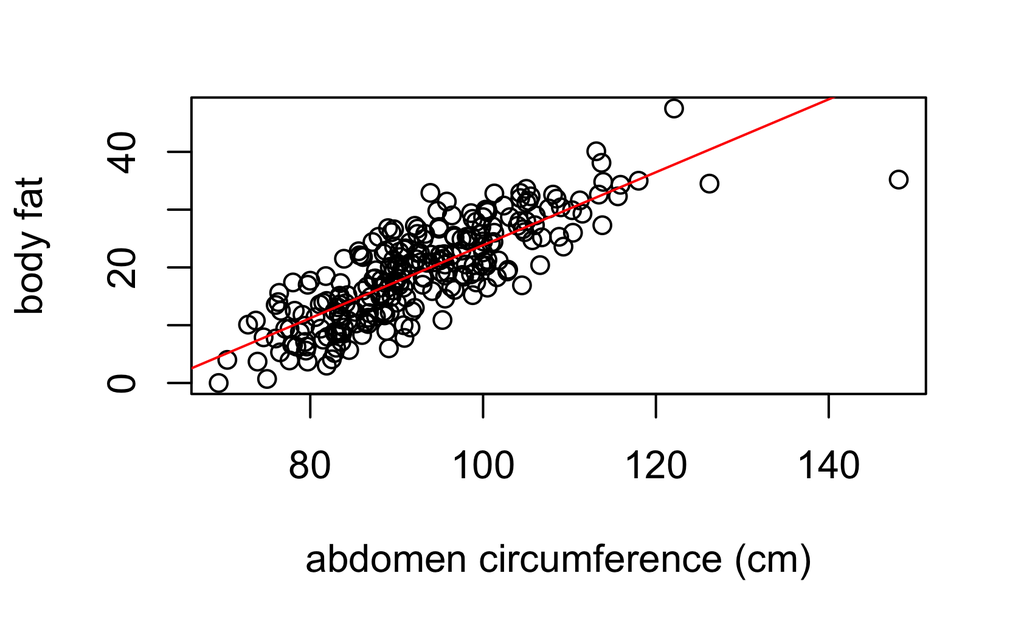

```r
plot(bodyfat$Abdomen,bodyfat$Bodyfat,xlab="abdomen circumference (cm)",ylab="body fat")
abline(beta,col='red')
```

We can easily obtain residuals, compute the MS, plot the residuals and make the QQ-plot.

REMEMBER: all this stuff if NOT Bayesian!!! We do this for comparison!! (bad experience with previous students!)

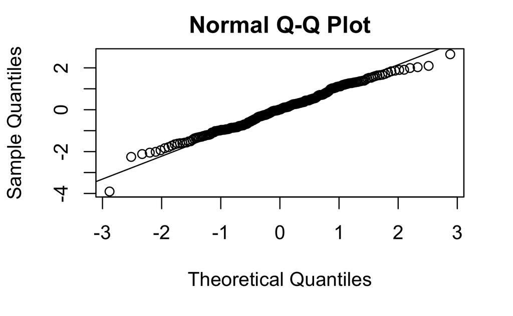

```r
resid = residuals(bodyfat.lm)
n = length(resid)
MSE = 1/ (n - 2) * sum((resid ^ 2))
qqnorm(resid/sd(resid))
qqline(resid/sd(resid))
```

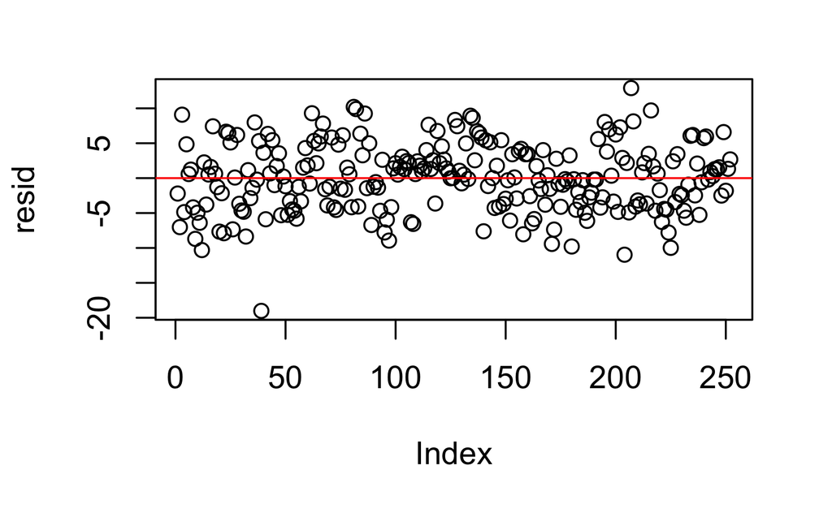

```r
plot(resid)
abline(h=0,col="red")
```

```r
MSE
```

```
[1] 23.78985
```

# Linear regression

In a normal linear regression problem, the likelihood is

$$y=(y_1,\dots,y_n) \sim \mathscr{N}_{n}(\beta_0 \mathbf{1} + \beta X, \sigma^2 I_n)
\quad \beta=(\beta_1,\dots,\beta_k)$$

where $\mathbf{1}$ is a vector of ones of length $n$ and $I_n$ is the identity matrix.

Again as warm up exercise, let us fit the full model above in a frequentistic way (MLE) using R.

```r
fulllm=lm(Bodyfat ~ ., data = bodyfat)
summary(fulllm)
```

```
Call:
lm(formula = Bodyfat ~ ., data = bodyfat)

Residuals:
     Min       1Q   Median       3Q      Max
-11.1687  -2.8639  -0.1014   3.2085  10.0068

Coefficients:
             Estimate Std. Error t value Pr(>|t|)
(Intercept) -18.18849   17.34857  -1.048  0.29551
Age           0.06208    0.03235   1.919  0.05618 .
Weight       -0.08844    0.05353  -1.652  0.09978 .
Height       -0.06959    0.09601  -0.725  0.46925
Neck         -0.47060    0.23247  -2.024  0.04405 *
Chest        -0.02386    0.09915  -0.241  0.81000
Abdomen       0.95477    0.08645  11.044  < 2e-16 ***
Hip          -0.20754    0.14591  -1.422  0.15622
Thigh         0.23610    0.14436   1.636  0.10326
Knee          0.01528    0.24198   0.063  0.94970
Ankle         0.17400    0.22147   0.786  0.43285
Biceps        0.18160    0.17113   1.061  0.28966
Forearm       0.45202    0.19913   2.270  0.02410 *
Wrist        -1.62064    0.53495  -3.030  0.00272 **
---
Signif. codes:
0 ‘***’ 0.001 ‘**’ 0.01 ‘*’ 0.05 ‘.’ 0.1 ‘ ’ 1

Residual standard error: 4.305 on 238 degrees of freedom
Multiple R-squared:  0.749, Adjusted R-squared:  0.7353
F-statistic: 54.65 on 13 and 238 DF,  p-value: < 2.2e-16
```

# Bayesian regression using BAS

We now use the BAS package to fit a Bayesian Linear Regression model. BAS is mainly designed to fit a hierarchy of nested models (including and excluding the various covariates) in order to perform model selection and model averaging. Here we use BAS just to fit one single (given) model. More will be done in the LAB sessions with the TA.

Omitting the prior description on $\beta_0$, recall that the (centered) Zellner prior is

$$\begin{split}
& \beta=(\beta_1,\dots,\beta_k) \\
\beta|\sigma^2,X &\sim \mathscr{N}_{k}(0,\alpha \sigma^2(X^t X)^{-1})\\
\sigma^2|X & \sim \pi(\sigma^{2})=\sigma^{-2} \qquad \alpha>0.
\end{split}$$

In the book $\alpha$ is $c$.

We take $\alpha=30$ and fit the model with BAS.

```r
alphapar=30
cog.bas = bas.lm(Bodyfat ~ ., data =  bodyfat, prior="g-prior",alpha=alphapar, modelprior = Bernoulli(1), include.always = ~ ., n.models = 1)
beta = coef(cog.bas)
beta
```

```
 Marginal Posterior Summaries of Coefficients:

 Using  BMA

 Based on the top  1 models
           post mean  post SD   post p(B != 0)
Intercept  19.15079    0.27121   1.00000
Age         0.06008    0.03182   1.00000
Weight     -0.08559    0.05266   1.00000
Height     -0.06735    0.09445   1.00000
Neck       -0.45542    0.22869   1.00000
Chest      -0.02309    0.09753   1.00000
Abdomen     0.92397    0.08504   1.00000
Hip        -0.20085    0.14354   1.00000
Thigh       0.22848    0.14201   1.00000
Knee        0.01479    0.23804   1.00000
Ankle       0.16838    0.21786   1.00000
Biceps      0.17574    0.16834   1.00000
Forearm     0.43744    0.19589   1.00000
Wrist      -1.56836    0.52625   1.00000
```

We plot the posterior densities of the $\beta$s.

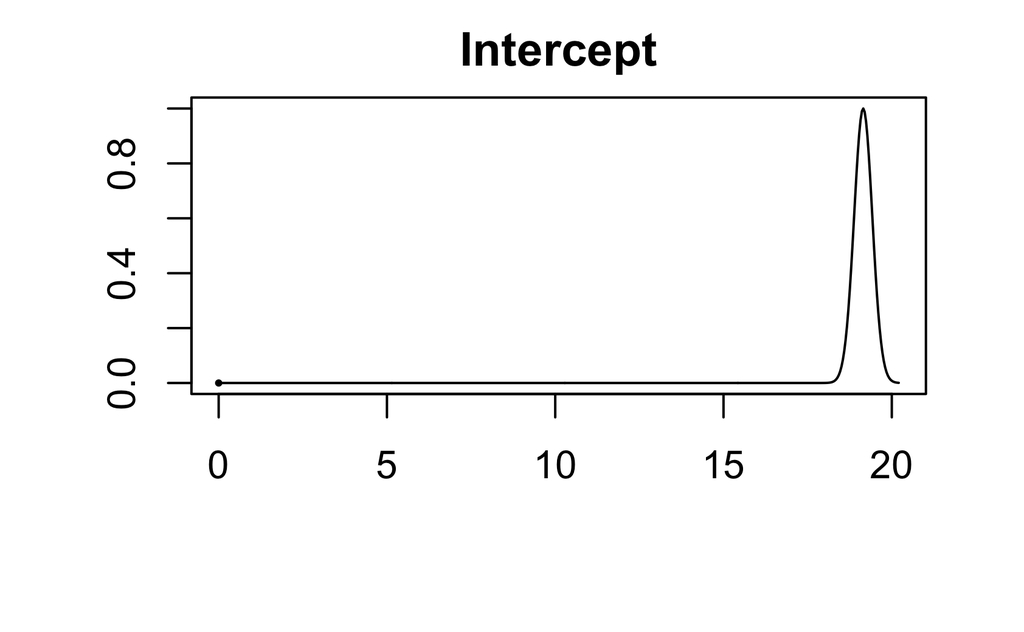

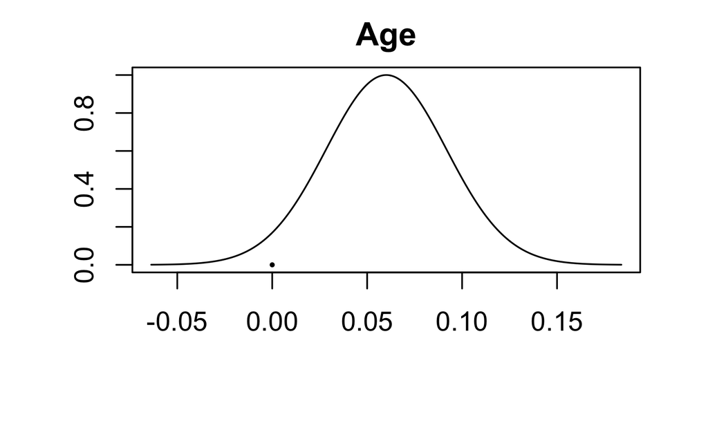

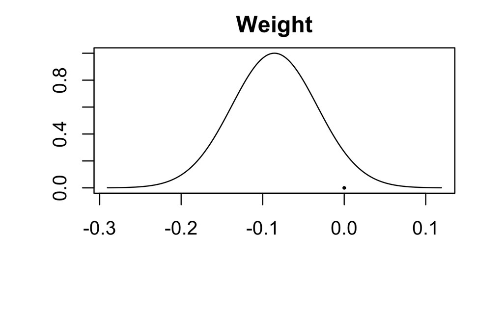

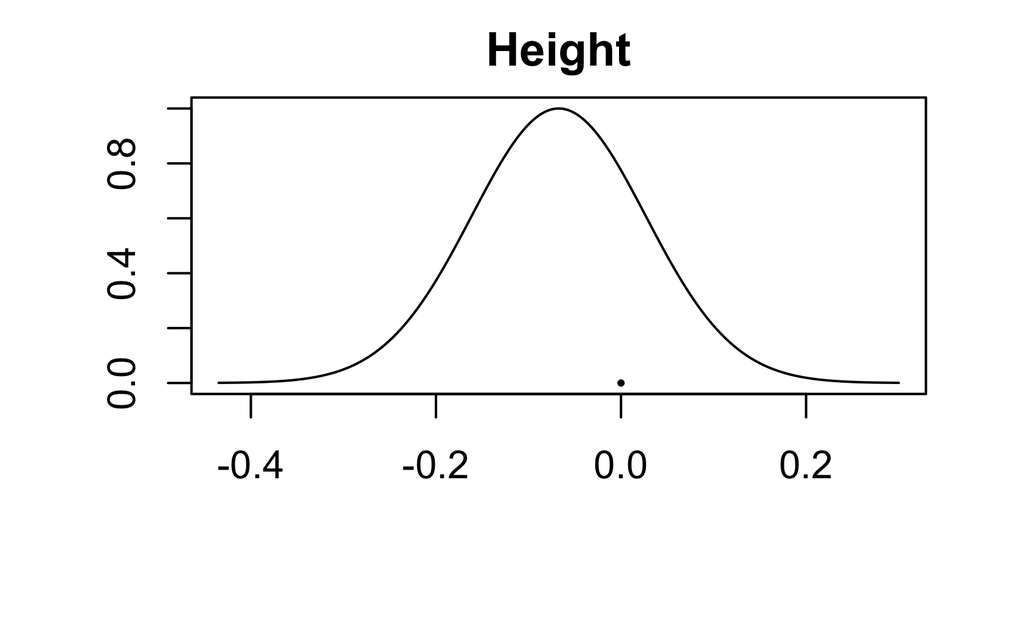

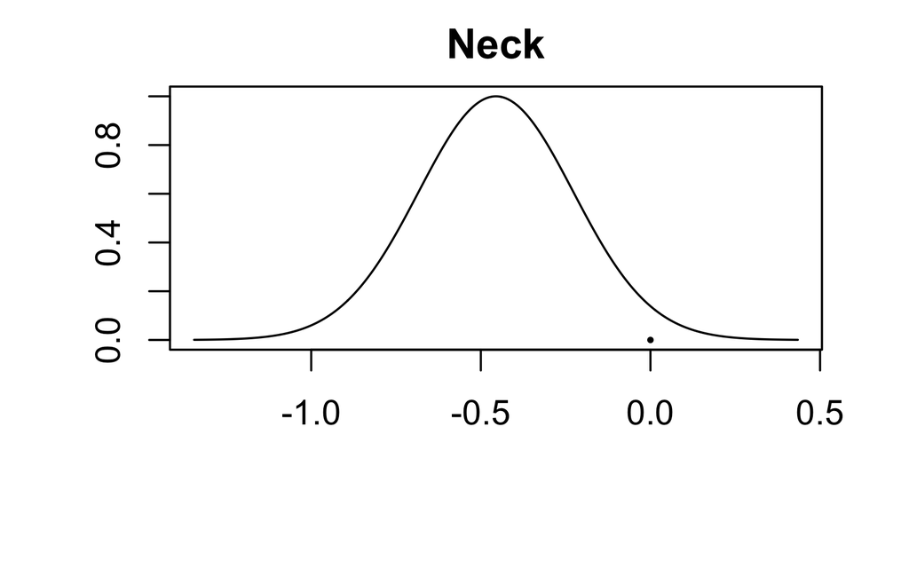

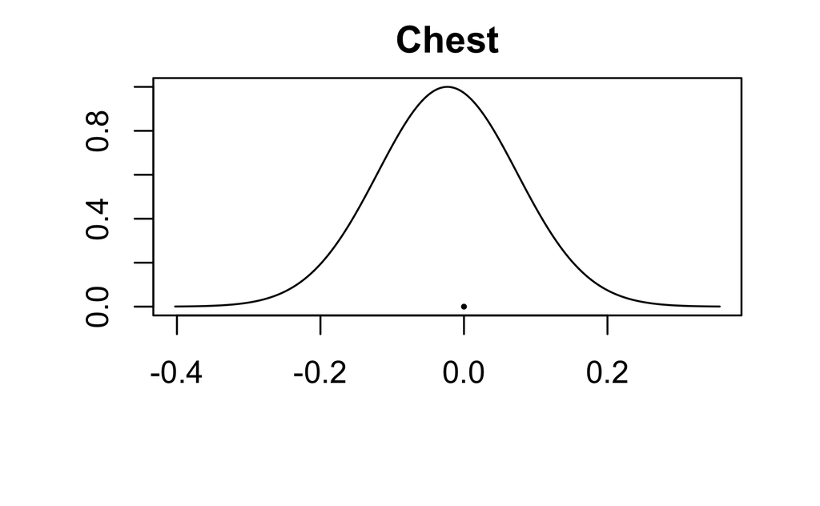

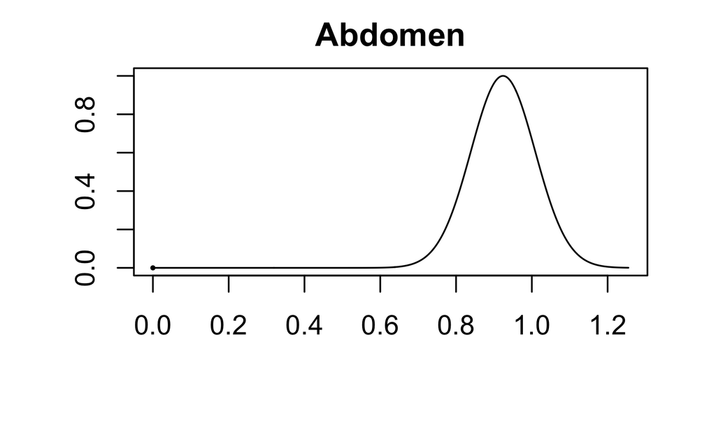

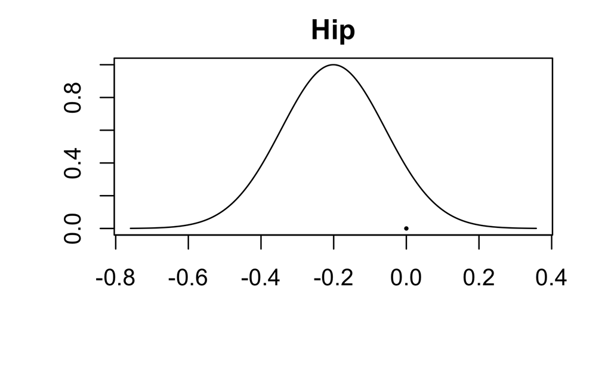

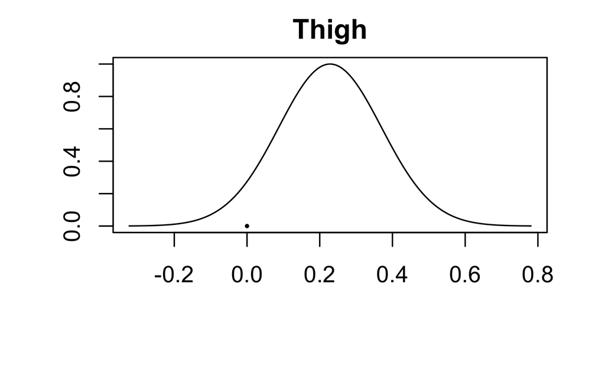

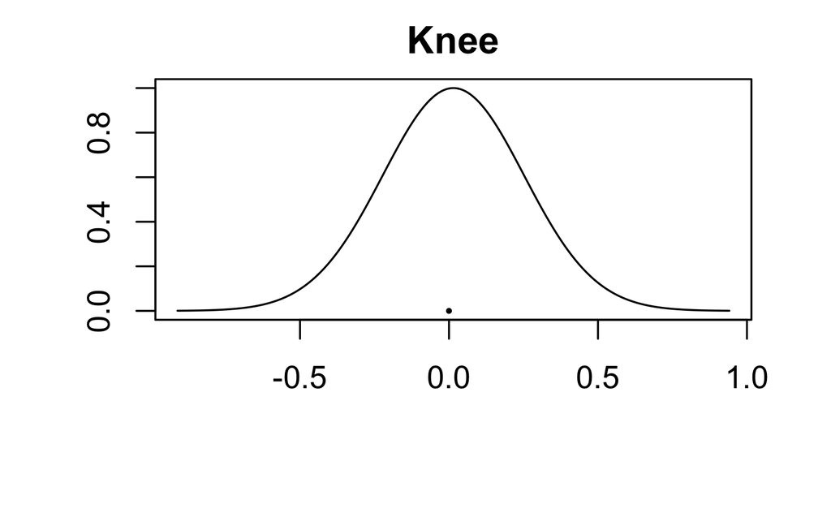

```r
plot(beta, subset = 1:10, ask = F)
```

```r
confint(beta)
```

```
                  2.5%        97.5%        beta
Intercept 18.616661094 19.684926208 19.15079365
Age       -0.002597702  0.122749920  0.06007611
Weight    -0.189293799  0.018110555 -0.08559162
Height    -0.253351501  0.118660347 -0.06734558
Neck      -0.905809523 -0.005029213 -0.45541937
Chest     -0.215184829  0.168996159 -0.02309434
Abdomen    0.756486284  1.091462343  0.92397431
Hip       -0.483537883  0.081845386 -0.20084625
Thigh     -0.051199941  0.508167382  0.22848372
Knee      -0.454026925  0.483603469  0.01478827
Ankle     -0.260693757  0.597458984  0.16838261
Biceps    -0.155799645  0.507288192  0.17574427
Forearm    0.051644270  0.823242661  0.43744347
Wrist     -2.604783424 -0.531937413 -1.56836042
attr(,"Probability")
[1] 0.95
attr(,"class")
[1] "confint.bas"
```

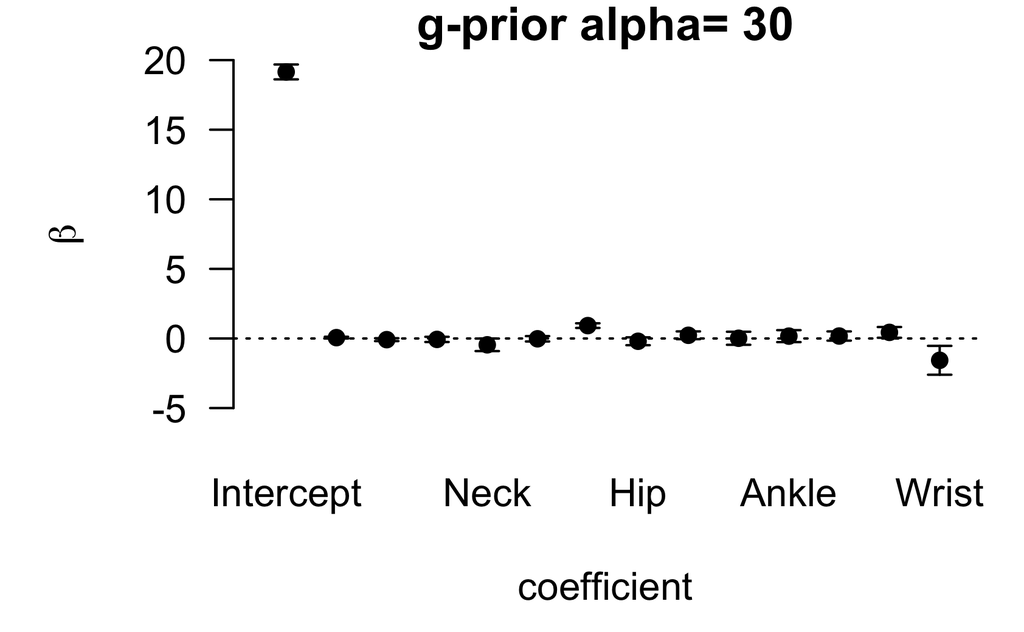

```r
plot(confint(beta),main=paste("g-prior alpha=",alphapar))
```

We now choose a suitable mxitrue of Zellner prior, more specifically the Zellner-Siow prior. A ZS prior is simply a mixture of Zellner prior, i.e.
$$\begin{split}
& \beta=(\beta_1,\dots,\beta_k) \\
\beta|\sigma^2,X &\sim \mathscr{N}_{k}(0,\alpha \sigma^2(X^t X)^{-1})\\
\sigma^2|X & \sim \pi(\sigma^{2})=\sigma^{-2} \\
& 1/\alpha \sim \pi_0 = Gamma(1/2,n/2)
\end{split}$$

Note that choosing other form for $\pi_0$ one obtains other Zellner type priors, some of them are implemented in BAS.

```r
cog.basZS = bas.lm(Bodyfat ~ ., data =  bodyfat, prior="JZS", modelprior = Bernoulli(1), include.always = ~ ., n.models = 1)
#plot(cog.basZS, which=4)
betaZS = coef(cog.basZS)
betaZS
```

```
 Marginal Posterior Summaries of Coefficients:

 Using  BMA

 Based on the top  1 models
           post mean  post SD   post p(B != 0)
Intercept  19.15079    0.27121   1.00000
Age         0.06118    0.03211   1.00000
Weight     -0.08717    0.05314   1.00000
Height     -0.06859    0.09531   1.00000
Neck       -0.46382    0.23079   1.00000
Chest      -0.02352    0.09843   1.00000
Abdomen     0.94102    0.08582   1.00000
Hip        -0.20455    0.14486   1.00000
Thigh       0.23270    0.14331   1.00000
Knee        0.01506    0.24023   1.00000
Ankle       0.17149    0.21987   1.00000
Biceps      0.17899    0.16989   1.00000
Forearm     0.44551    0.19769   1.00000
Wrist      -1.59729    0.53108   1.00000
```

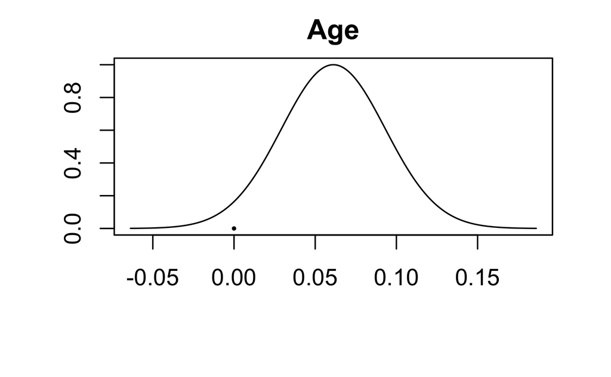

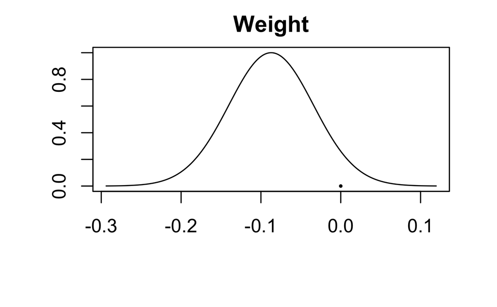

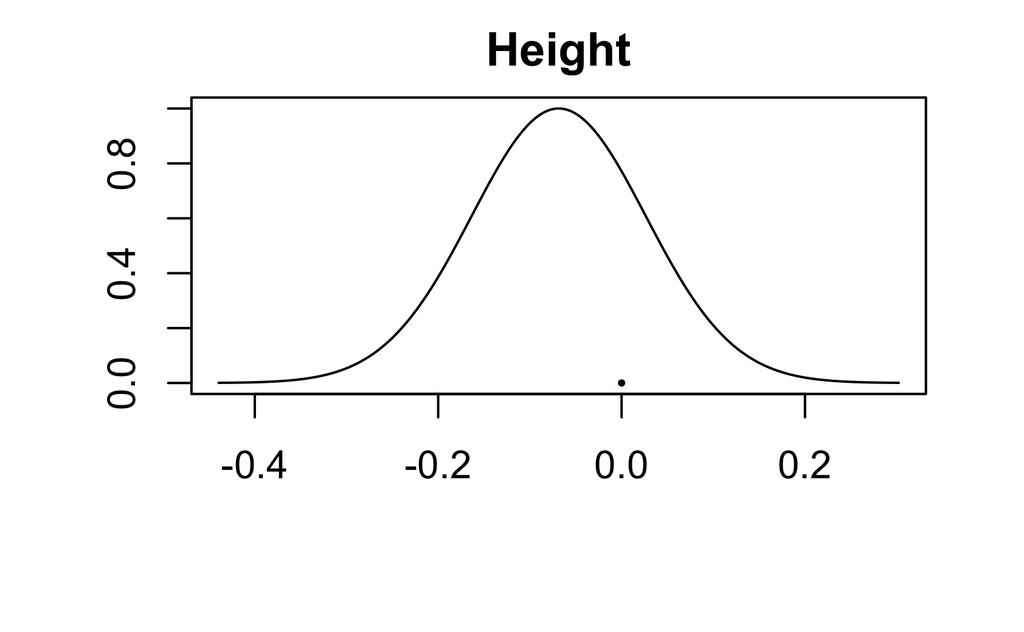

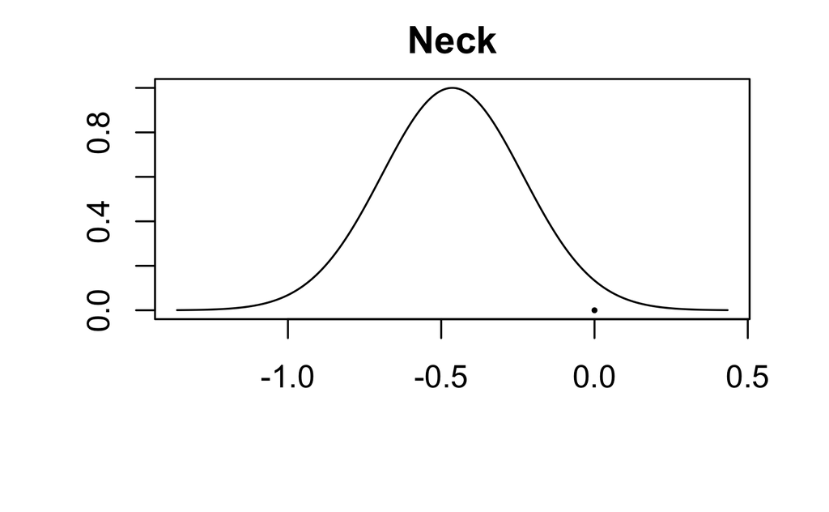

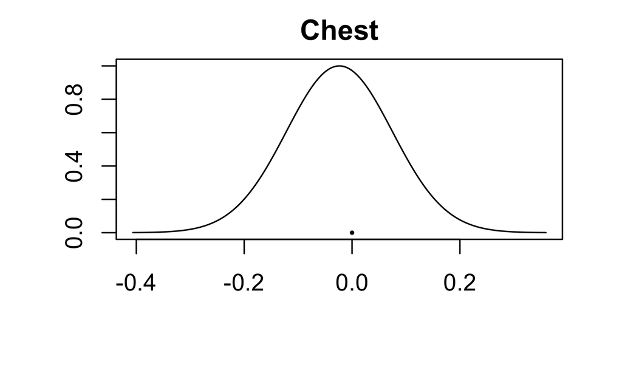

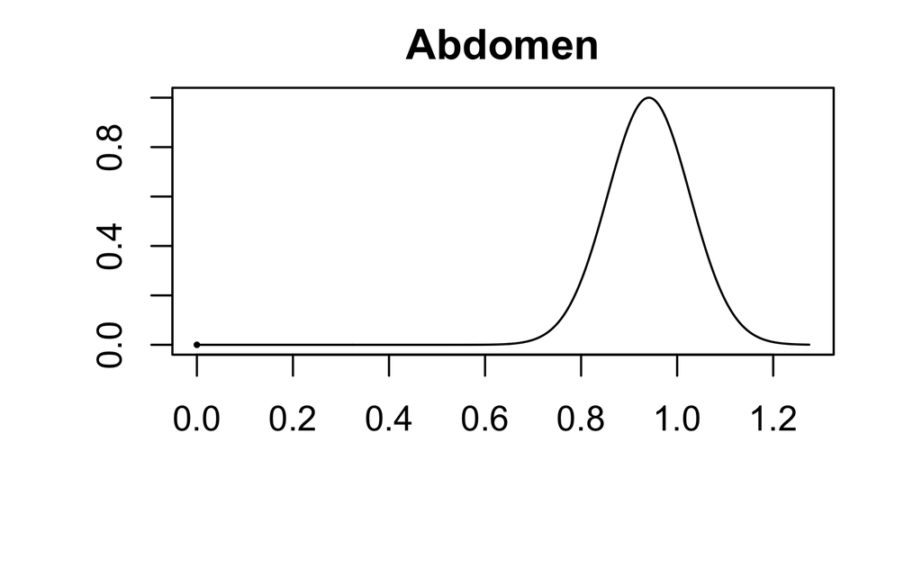

```r
plot(betaZS,subset = 2:7, ask = F)
```

Let us compare the $\beta$s estimates under the two different priors

```r
par(mfrow=c(2,2))
plot(confint(beta),main=paste("g-prior alpha=",alphapar))
```

```r
confint(betaZS)
```

```
                  2.5%       97.5%        beta
Intercept 18.616661094 19.68492621 19.15079365
Age       -0.002064952  0.12443344  0.06118424
Weight    -0.191824625  0.01748383 -0.08717040
Height    -0.256301367  0.11912577 -0.06858780
Neck      -0.918344799 -0.00929479 -0.46381979
Chest     -0.217374320  0.17033368 -0.02352032
Abdomen    0.771991789  1.11004313  0.94101746
Hip       -0.489837865  0.08073596 -0.20455095
Thigh     -0.049553113  0.51494954  0.23269821
Knee      -0.458058151  0.48818025  0.01506105
Ankle     -0.261527036  0.60450406  0.17148851
Biceps    -0.155601729  0.51357365  0.17898596
Forearm    0.056171256  0.83485338  0.44551232
Wrist     -2.643227557 -0.55135158 -1.59728957
attr(,"Probability")
[1] 0.95
attr(,"class")
[1] "confint.bas"
```

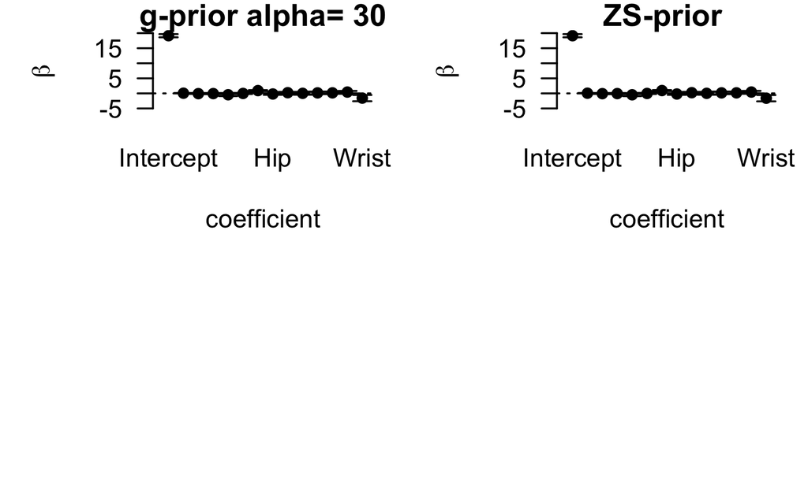

```r
plot(confint(betaZS),main="ZS-prior ")
```

BAS has methods defined to return fitted values using the observed design matrix and predictions at either the observed data or potentially new values, as with lm.

```r
n=40
nend=length(bodyfat[,1])
newdata<-bodyfat[1:n,]
datalearning<-bodyfat[seq(n+1,nend),]
#dim(datalearning)
rownames(datalearning)=seq(1:length(datalearning[,1]))

cog.basZS2 = bas.lm(Bodyfat ~ ., data =  datalearning, prior="JZS", modelprior = Bernoulli(1), include.always = ~ ., n.models = 1)
betaZS2 = coef(cog.basZS2)
#plot(confint(betaZS2),main="ZS-prior ")



fitted<-predict(cog.basZS2, estimator = "BMA")
prednew <- predict(cog.basZS2,newdata=newdata, estimator = "BMA")
```

Below we plot true values vs fitted and predicted. Black points are true vs fitted in the learning dataset and red points are true vs predicted in the additional part of the data set (not used for fitting the model).

```r
plot(fitted$Ypred[1:length(fitted$Ypred)],datalearning$Bodyfat[1:length(fitted$Ypred)],
  pch = 16,
  xlab = expression(hat(mu[i])), ylab = 'Y',type="p")


points(prednew$Ypred, newdata$Bodyfat,
  pch = 16,
  col="red",type="p"
)
```

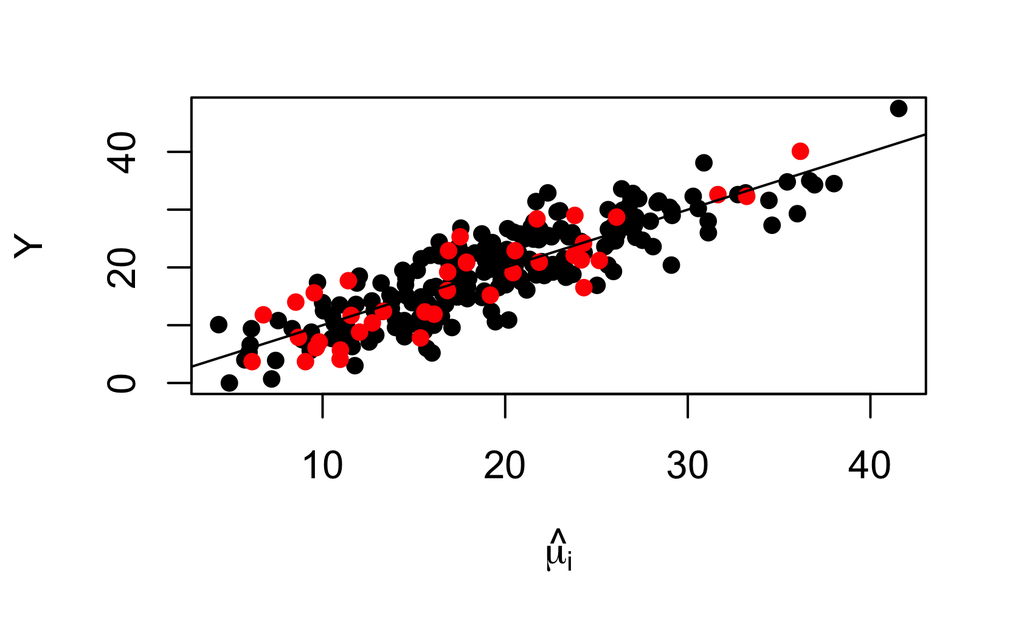

```r
abline(0, 1)
```

```r
#prednew$Ypred
#newdata$Bodyfat


BPM <- predict(cog.basZS2, estimator = "BPM", newdata=newdata,se.fit = TRUE)
conf.fit <- confint(BPM, parm = "mean")
conf.pred <- confint(BPM, parm = "pred")
plot(conf.pred, main="Out of sample: pred. (black) vs true (red)")
```

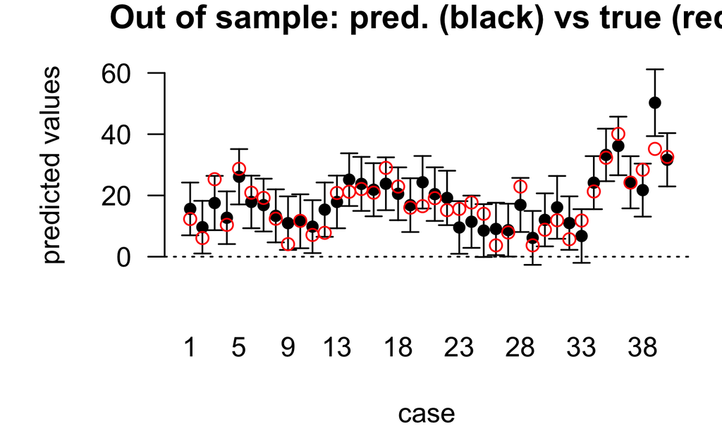

```r
points(seq(1:n),newdata$Bodyfat,col="red")
```

For much more see https://cran.r-project.org/web/packages/BAS/vignettes/BAS-vignette.html

see also https://www.sciencedirect.com/science/article/pii/S030440761200156X